# Classification

Author

Landon Waters

Published

February 24, 2025

**Abstract:**

This is a technical blog post of **both** an HTML file *and* [.qmd file](https://raw.githubusercontent.com/cd-public/D505/refs/heads/master/hws/src/classify.qmd) hosted on GitHub pages.

# 1. Setup

**Set Up Code:**

```r
sh <- suppressPackageStartupMessages
sh(library(tidyverse))
sh(library(caret))
sh(library(tidytext))
sh(library(SnowballC))
sh(library(pROC))
sh(library(glmnet))
data(stop_words)
wine <- readRDS(gzcon(url("https://github.com/cd-public/D505/raw/master/dat/pinot.rds")))
```

# 2. Logistic Concepts

Why do we call it Logistic Regression even though we are using the technique for classification?

> TODO: *It is called a regression because we are still applying a variation of the regression formula to the data. What makes it a classification is the fact that we are trying to predict a discrete, binary output using the logistic formula. When we apply the logistic function to the predictors it transforms them into probabilities between 1 and 0. For example, if the value is closer to 1 then 0, then it classifies it as a 1.*

# 3. Modeling

**Useful functions:**

```r
desc_to_words <- function(df, omits) {
  df %>%
    unnest_tokens(word, description) %>%
    anti_join(stop_words) %>% # get rid of stop words
    filter(!(word %in% omits))
}

words_to_stems <- function(df) {
  df %>%
    mutate(word = wordStem(word))
}

filter_by_count <- function(df, j) {
  df %>%
    count(id, word) %>%
    group_by(id) %>% mutate(exists = (n>0)) %>% ungroup %>%
    group_by(word) %>%
    mutate(total = sum(n)) %>%
    filter(total > j)
}

pivoter <- function(words, df) {
  words %>%
    pivot_wider(id_cols = id, names_from = word, values_from = exists, values_fill = list(exists=0)) %>%
    right_join(select(df,id,province)) %>%
    drop_na() %>%
    select(-id)
}

wine_words <- function(df, j, stem) {

  words <- desc_to_words(df, c("wine","pinot","vineyard"))

  if (stem) {
    words <- words_to_stems(words)
  }

  words <- filter_by_count(words, j)

  pivoter(words, df)
}

get_odds <- function(fit) {
  as.data.frame(t(exp(coef(fit$finalModel))))   %>%
  rownames_to_column(var = "name") %>%
  pivot_longer(-name, names_to = "class", values_to = "odds") %>%
  arrange(desc(odds)) %>%
  head()
}

get_fit <- function(df, control) {
  train(marlborough ~ .,
        data = df,
        trControl = control,
        method = "glm",
        family = "binomial")
}

get_matrix <- function(fit, df) {
  pred <- factor(predict(fit, newdata = df))
  confusionMatrix(pred,factor(df$marlborough))
}
```

We train a logistic regression algorithm to classify a whether a wine comes from Marlborough using:

1. An 80-20 train-test split.
2. Three features engineered from the description
3. 5-fold cross validation.

We report Kappa after using the model to predict provinces in the holdout sample.

To start, we will create a model with the “kitchen sink” of features that includes a binary feature for any stem that occurs more than 1000 times.

```r
# TODO
set.seed(505)

# Token-ize description, remove stop words, reduce words to stems, filter to
# words occurring more than 1000 times, pivot/create binary features for
# logistic regression
wino <- suppressMessages(wine_words(wine, 1000, T))

wino <- wino %>%
  mutate(marlborough = factor(province=="Marlborough")) %>%
  select(-province)

# 80-20 train-test split
wine_index <- createDataPartition(wino$marlborough, p = 0.80, list = FALSE)
train <- wino[ wine_index, ]
test <- wino[-wine_index, ]

# 5-fold cross validation using logistic regression algorithm
control = trainControl(method = "cv", number = 5)

fit <- get_fit(train, control)

# Change the threshold to 0.4 due to high False Negative rate
prob <- predict(fit, newdata = test, type = "prob")[,2] # take positive predictions
pred <- factor(ifelse(prob > 0.4, "TRUE", "FALSE"), levels = c("FALSE", "TRUE"))

confusionMatrix(pred, test$marlborough, positive = "TRUE")$overall["Kappa"]
```

```
    Kappa
0.4985952
```

```r
get_odds(fit)
```

```
# A tibble: 6 × 3
  name  class       odds
  <chr> <chr>      <dbl>
1 1     drinkTRUE  17.2
2 1     bodiTRUE    4.74
3 1     finishTRUE  3.43
4 1     cherriTRUE  2.61
5 1     texturTRUE  1.91
6 1     aromaTRUE   1.71
```

Using the most common stems, we can create our 3 engineered features and make another model.

```r
set.seed(505)

# features do not seem very distinct, small sample of wines
wino2<-wino%>%
  select(drink, bodi, finish, marlborough)

wine_index2 <- createDataPartition(wino2$marlborough, p = 0.80, list = FALSE)
train2 <- wino2[ wine_index2, ]
test2 <- wino2[-wine_index2, ]

control2 = trainControl(method = "cv", number = 5)
fit2 <- get_fit(train2, control2)

prob2 <- predict(fit2, newdata = test2, type = "prob")[,2]
pred2 <- factor(ifelse(prob2 > 0.4, "TRUE", "FALSE"), levels = levels(test2$marlborough))
# interesting, slightly changing the threshold has no effect on the kappa on this simpler model

# including threshold change
# confusionMatrix(pred2, test2$marlborough, positive = "TRUE")$overall["Kappa"]

# excluding threshold change
get_matrix(fit2, test2)$overall["Kappa"]
```

```
    Kappa
0.2471732
```

# 4. Binary vs Other Classification

What is the difference between determining some form of classification through logistic regression versus methods like $K$-NN and Naive Bayes which performed classifications.

> TODO: *The main difference is that $K$-NN and Naive Bayes support multi-class classification, while logistic regression is designed for binary classification primarily.*

# 5. ROC Curves

We can display an ROC for the model to explain your model’s quality.

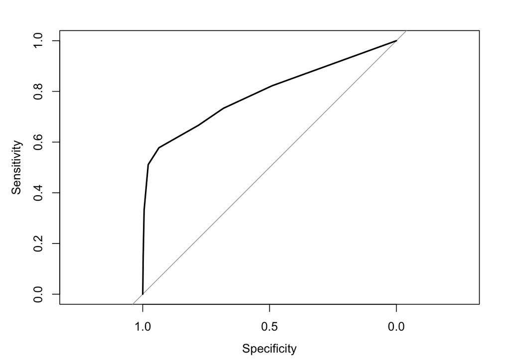

```r
# You can find a tutorial on ROC curves here:
# https://towardsdatascience.com/understanding-the-roc-curve-and-auc-dd4f9a192ecb/

myRoc <- roc(test2$marlborough, prob2)
plot(myRoc)
```

```r
auc(myRoc)
```

```
Area under the curve: 0.7924
```

> TODO: *The curve is relatively close to the top left corner which indicates that the model is doing a solid job of distinguishing between Marlborough and non-Marlborough wines. The AUC value of 0.7924 suggests decent predictive performance, well above the 0.5 threshold for random guessing. This is another sign that the model is relatively good at predicting the wines correctly. Despite the limited sample size of Marlborough wines, the model demonstrates solid predictive ability.*